# Homework GROUP 46

Antonio Pagnotta, Beatrice Mazzocchi, Domenico Mangieri

2026-02-14

## 0.1 1. Experiment Overview

The objective of this study is to analyze **human kinematic behavior** captured via mobile sensing. By collecting multivariate functional data, we aim to categorize and study distinct activity phases using **Functional Data Analysis (FDA)** techniques.

## 0.2 2. Protocol and Instrumentation

To ensure data fidelity and reproducibility, the following setup was employed:

- **Device:** Smartphone.
- **Application:** Arduino Science Journal.
- **Primary Sensor:** Linear Accelerometer.
  - *Rationale:* This sensor measures acceleration excluding gravity, making it the optimal choice for pure motion quantification.

## 0.3 3. Experimental Timeline

Data was captured in a **single continuous sequential session**. This approach provides a holistic view of transition states between three distinct phases:

| Phase | Activity Type | Signal Characteristics |
| --- | --- | --- |
| **Running** | High Intensity | High variance and large amplitude. |
| **Sedentary** | Rest/Baseline | Minimal variance; representative of the noise floor. |
| **Walking** | Moderate (Grocery Shopping) | Intermediate variance and rhythmic patterns. |

## 0.4 4. Data Structure & FDA Transformation

The raw output is an asynchronous time-series log. To transition from standard time-series analysis to **Functional Data Analysis**, we apply a windowing transformation:

1. **Segmentation:** The continuous stream is divided into short, fixed-duration “epochs.”
2. **Functional Mapping:** Each window is treated as a single functional observation $X_i(t)$.
3. **Domain:** $t \in [0, T]$, where $T$ is the duration of the epoch.

> **Note:** This transformation allows us to analyze the *shape* and *dynamics* of the motion rather than just individual, discrete data points.
2. Data Handling and Preprocessing Here we import the raw CSV, handle missing values caused by asynchronous sensor sampling, and segment the continuous stream into function curves.

```r
# 1. Load Data
# NOTE: Ensure the file is in your working directory
raw_data <- read.csv("dati_sgravati (1).csv")

# 2. Selection and Cleaning
# We focus on LinearAccelerometerSensor.
# If unavailable, we could calculate Magnitude from AccX, AccY, AccZ.
df <- raw_data[, c("timestamp", "LinearAccelerometerSensor")]

# Sort by timestamp
df <- df[order(df$timestamp), ]

# Handle Missing Values (Interpolation)
# The sensor is asynchronous; we interpolate to fill NaNs.
df$LinearAccelerometerSensor <- na.approx(df$LinearAccelerometerSensor, rule = 2)

# 3. Segmentation (Creating Functions)
# We slice the continuous signal into 2-second windows to create our sample of curves.
# Assuming ~20ms sampling rate (50Hz), 2 seconds is approx 100 points.
window_size <- 100
n_points <- nrow(df)
n_curves <- floor(n_points / window_size)

# Create a Matrix of Data (Rows = Curves, Cols = Time Points)
data_mat <- matrix(NA, nrow = n_curves, ncol = window_size)

for(i in 1:n_curves){
  idx_start <- (i-1)*window_size + 1
  idx_end <- i*window_size
  data_mat[i, ] <- df$LinearAccelerometerSensor[idx_start:idx_end]
}

# Create time grid for a single curve (normalized 0 to 1)
time_grid <- seq(0, 1, length.out = window_size)

cat("Data Segmentation Complete:\n")
```

```
## Data Segmentation Complete:
```

```r
cat("Number of Functional Observations (N):", n_curves, "\n")
```

```
## Number of Functional Observations (N): 1122
```

```r
cat("Time points per curve (P):", window_size, "\n")
```

```
## Time points per curve (P): 100
```

3. Functional Data Analysis (FDA) We represent the discrete data points as smooth functions using B-splines and perform Functional Principal Component Analysis (FPCA) to reduce dimensionality.

```r
# 1. Create Functional Objects
# We use a B-spline basis.
# nbasis = 15 gives enough flexibility for accelerometer data without overfitting.
basis <- create.bspline.basis(rangeval = c(0, 1), nbasis = 15, norder = 4)
fd_obj <- smooth.basis(time_grid, t(data_mat), basis)$fd

# 2. Functional PCA
# We project the curves onto the principal components (Eigenfunctions).
# This corresponds to the "Projection" approach in Section 3 of the paper.
pca_res <- pca.fd(fd_obj, nharm = 4)

# Extract Scores (The coefficients \xi in the paper)
scores <- pca_res$scores
eigen_functions <- pca_res$harmonics

# Visualize the Mean Function and First Eigenfunction
par(mfrow=c(1,2))
plot(pca_res$meanfd, main = "Mean Function")
```

```
## [1] "done"
```

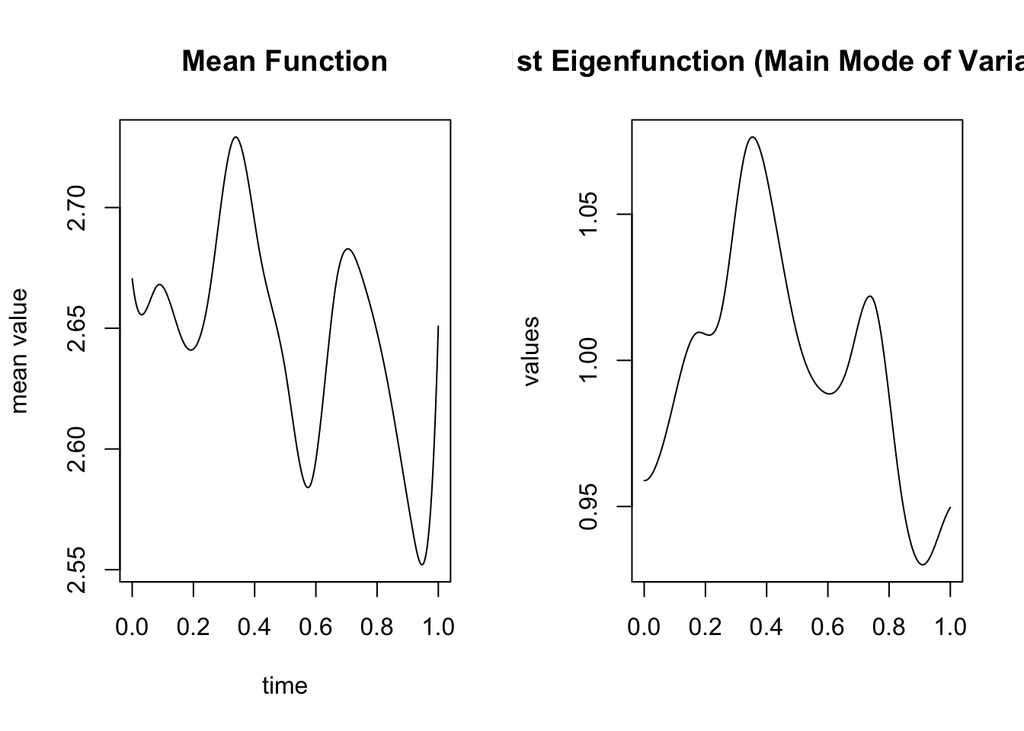

```
## [1] "done"
```

```r
plot(eigen_functions[1], main = "1st Eigenfunction (Main Mode of Variation)")
```

4. Conformal Prediction ImplementationWe implement the Inductive Conformal Prediction method (Section 3 of the main paper) using the Gaussian Approximation (Section 3.1) for the conformity scores.The Logic:Split Data: Divide curves into Training ($D_{train}$) and Calibration ($D_{cal}$) sets.Estimate Density: Assume the PC scores follow a Gaussian distribution (Ellipsoid in k-dimensions). We calculate the Mean ($\mu$) and Covariance ($\Sigma$) on $D_{train}$.Conformity Score: Calculate the Mahalanobis distance of the calibration points from the center. This measures how “normal” a curve is.Calibration: Find the $(1-\alpha)$ quantile of these distances ($r^2$). This defines the boundary of an ellipsoid containing 90% of the data.Band Construction: Project this ellipsoid back to function space. The band width at time $t$ is proportional to the standard deviation of the process at time $t$.

```r
# Parameters
alpha <- 0.1  # 90% Confidence
set.seed(123)

# 1. Split Data
n <- nrow(scores)
train_idx <- sample(1:n, size = floor(n/2))
calib_idx <- setdiff(1:n, train_idx)

scores_train <- scores[train_idx, ]
scores_calib <- scores[calib_idx, ]

# 2. Fit Gaussian (Mean and Covariance on Training)
mu_vec <- colMeans(scores_train)
sigma_mat <- cov(scores_train)

# 3. Compute Conformity Scores (Mahalanobis Distance) on Calibration Set
# The score measures how far a curve is from the center of the distribution
calib_dists <- mahalanobis(scores_calib, center = mu_vec, cov = sigma_mat)

# 4. Compute Quantile (The Radius of the Ellipsoid)
# We find k such that 90% of calibration distances are <= k
k_quantile <- quantile(calib_dists, probs = (1 - alpha) * (1 + 1/length(calib_dists)))

cat("Conformal Threshold (Mahalanobis Distance):", k_quantile, "\n")
```

```
## Conformal Threshold (Mahalanobis Distance): 5.697347
```

```r
# 5. Construct Prediction Bands
# The formula for the max/min of the function subject to the ellipsoid constraint:
# Band(t) = Mean(t) +/- sqrt( k * diag( Phi(t) * Sigma * Phi(t)^T ) )
# Where Phi(t) is the vector of basis functions (or eigenfunctions) at time t.

# Evaluate Eigenfunctions on a dense grid for plotting
plot_grid <- seq(0, 1, length.out = 100)
phi_eval <- eval.fd(plot_grid, eigen_functions) # Matrix: 100 x nharm

# Calculate Variance factor at each time point: diag( Phi * Sigma * Phi' )
var_t <- diag(phi_eval %*% sigma_mat %*% t(phi_eval))

# Mean function evaluated
mean_eval <- eval.fd(plot_grid, pca_res$meanfd)

# Calculate Upper and Lower bounds
width_t <- sqrt(k_quantile * var_t)
lower_bound <- mean_eval - width_t
upper_bound <- mean_eval + width_t
```

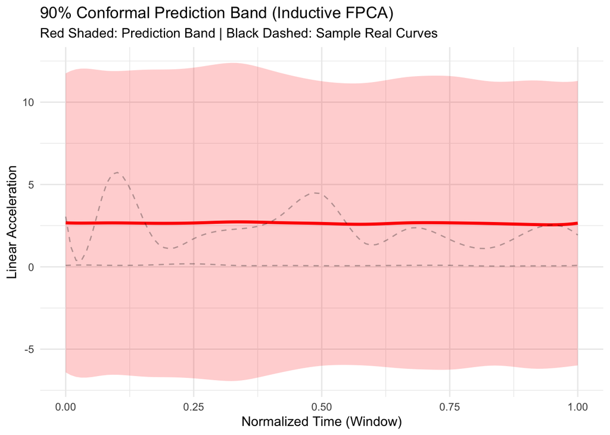

```r
# Prepare data for plotting
plot_df <- data.frame(
  Time = plot_grid,
  Mean = as.vector(mean_eval),
  Lower = as.vector(lower_bound),
  Upper = as.vector(upper_bound)
)

# Plot
p <- ggplot(plot_df, aes(x = Time)) +
  # Add the Prediction Band
  geom_ribbon(aes(ymin = Lower, ymax = Upper), fill = "red", alpha = 0.2) +
  geom_line(aes(y = Mean), color = "red", size = 1.2) +

  # Overlay a few random calibration curves to check coverage
  geom_line(data = data.frame(Time = plot_grid,
                              Value = eval.fd(plot_grid, fd_obj[calib_idx[1]])),
            aes(y = Value), color = "black", alpha = 0.3, linetype="dashed") +
  geom_line(data = data.frame(Time = plot_grid,
                              Value = eval.fd(plot_grid, fd_obj[calib_idx[10]])),
            aes(y = Value), color = "black", alpha = 0.3, linetype="dashed") +

  labs(title = "90% Conformal Prediction Band (Inductive FPCA)",
       subtitle = "Red Shaded: Prediction Band | Black Dashed: Sample Real Curves",
       y = "Linear Acceleration", x = "Normalized Time (Window)") +
  theme_minimal()

print(p)
```